# Capstone project final report - code

### Foursquare venues

|  | City | Country | lat | lon |
| --- | --- | --- | --- | --- |
| 0 | Vienna | Austria | 48.208354 | 16.372504 |
| 1 | Brussels | Belgium | 50.846557 | 4.351697 |
| 2 | Sofia | Bulgaria | 42.697863 | 23.322179 |
| 3 | Zagreb | Croatia | 45.813177 | 15.977048 |
| 4 | Prague | Czech Republic | 50.087465 | 14.421254 |

```
100
```

```
1.0
```

```
Londonrghn
```

```
City
Kuopio        27
Amsterdam    100
Madrid       100
Marseille    100
Milan        100
Name: Venue_Category, dtype: int64
```

Remove the city that does not return the max venues

```
Country           100
lat               100
lon               100
Venue_Category    100
dtype: int64
```

|  | City | Country | lat | lon | Venue_Category |
| --- | --- | --- | --- | --- | --- |
| 0 | Vienna | Austria | 48.208354 | 16.372504 | Plaza |
| 1 | Vienna | Austria | 48.208354 | 16.372504 | Church |
| 2 | Vienna | Austria | 48.208354 | 16.372504 | Restaurant |
| 3 | Vienna | Austria | 48.208354 | 16.372504 | Cocktail Bar |
| 4 | Vienna | Austria | 48.208354 | 16.372504 | Pedestrian Plaza |

|  | City | Art Gallery | Bar | Church | Cocktail Bar | Concert Hall | Italian Restaurant | Park | Pedestrian Plaza | Plaza | Restaurant | Sandwich Place | Shopping Mall | Theater |
| --- | --- | --- | --- | --- | --- | --- | --- | --- | --- | --- | --- | --- | --- | --- |
| 0 | Brussels | 0.0 | 0.2 | 0.0 | 0.0 | 0.4 | 0.0 | 0.0 | 0.0 | 0.0 | 0.0 | 0.2 | 0.2 | 0.0 |
| 1 | Sofia | 0.2 | 0.0 | 0.0 | 0.0 | 0.0 | 0.4 | 0.2 | 0.0 | 0.0 | 0.0 | 0.0 | 0.0 | 0.2 |
| 2 | Vienna | 0.0 | 0.0 | 0.2 | 0.2 | 0.0 | 0.0 | 0.0 | 0.2 | 0.2 | 0.2 | 0.0 | 0.0 | 0.0 |

```
35 Cities
300 Venue categories
```

|  | City | Café | Church | Restaurant |
| --- | --- | --- | --- | --- |
| 0 | Amsterdam | 0.04 | 0.00 | 0.04 |
| 1 | Athens | 0.07 | 0.00 | 0.00 |
| 2 | Barcelona | 0.01 | 0.00 | 0.02 |
| 3 | Belgrade | 0.05 | 0.00 | 0.07 |
| 4 | Bergen | 0.07 | 0.00 | 0.05 |
| 5 | Berlin | 0.02 | 0.00 | 0.01 |
| 6 | Brussels | 0.01 | 0.00 | 0.01 |
| 7 | Bucharest | 0.02 | 0.01 | 0.04 |
| 8 | Budapest | 0.02 | 0.01 | 0.04 |
| 9 | Copenhagen | 0.08 | 0.00 | 0.02 |

### Assemble the data

|  | Country | City | lat | lon | Jan | Feb | Mar | Apr | May | Jun | Jul | Aug | Sep | Oct | Nov | Dec | Year | job_index |
| --- | --- | --- | --- | --- | --- | --- | --- | --- | --- | --- | --- | --- | --- | --- | --- | --- | --- | --- |
| 0 | Austria | Vienna | 48.208354 | 16.372504 | 0.3 | 1.5 | 5.7 | 10.7 | 15.7 | 18.7 | 20.8 | 20.2 | 15.4 | 10.2 | 5.1 | 1.1 | 10.4 | 0.012060 |
| 1 | Belgium | Brussels | 50.846557 | 4.351697 | 3.3 | 3.7 | 6.8 | 9.8 | 13.6 | 16.2 | 18.4 | 18.0 | 14.9 | 11.1 | 6.8 | 3.9 | 10.5 | 0.027982 |
| 2 | Bulgaria | Sofia | 42.697863 | 23.322179 | -0.5 | 1.1 | 5.4 | 10.6 | 15.4 | 18.9 | 21.2 | 21.0 | 16.5 | 11.3 | 5.1 | 0.7 | 10.6 | 0.004805 |
| 3 | Croatia | Zagreb | 45.813177 | 15.977048 | 0.3 | 2.3 | 6.4 | 10.7 | 15.8 | 18.8 | 20.6 | 20.1 | 15.9 | 10.5 | 5.0 | 1.4 | 10.7 | 0.000188 |
| 4 | Czech Republic | Prague | 50.087465 | 14.421254 | -1.4 | -0.4 | 3.6 | 8.4 | 13.4 | 16.1 | 18.2 | 17.8 | 13.5 | 8.5 | 3.1 | -0.3 | 8.4 | 0.011212 |

|  | Country | City | lat | lon |
| --- | --- | --- | --- | --- |
| 0 | Netherlands | Amsterdam | 52.374540 | 4.897976 |
| 1 | Greece | Athens | 37.984149 | 23.727984 |
| 2 | Spain | Barcelona | 41.382894 | 2.177432 |
| 3 | Serbia | Belgrade | 44.817813 | 20.456897 |

## Analysis

### Data preparation

```
(35, 314)
```

|  | City | Jan | Feb | Mar | Apr | May | Jun | Jul | Aug | Sep | Oct | Nov | Dec | job_index | Accessories Store | Adult Boutique |
| --- | --- | --- | --- | --- | --- | --- | --- | --- | --- | --- | --- | --- | --- | --- | --- | --- |
| 0 | Amsterdam | 3.4 | 3.5 | 6.1 | 9.1 | 12.9 | 15.4 | 17.6 | 17.5 | 14.7 | 11.0 | 7.1 | 4.0 | 0.064161 | 0.0 | 0.0 |
| 1 | Athens | 10.2 | 10.8 | 13.1 | 16.8 | 21.7 | 26.6 | 29.3 | 29.2 | 25.0 | 20.1 | 15.4 | 11.5 | 0.003392 | 0.0 | 0.0 |
| 2 | Barcelona | 11.8 | 12.4 | 14.2 | 15.8 | 19.3 | 23.0 | 25.7 | 26.1 | 23.0 | 19.5 | 14.9 | 12.3 | 0.025532 | 0.0 | 0.0 |
| 3 | Belgrade | 1.4 | 3.1 | 7.6 | 12.9 | 18.1 | 21.0 | 23.0 | 22.7 | 18.0 | 12.9 | 7.1 | 2.7 | 0.000283 | 0.0 | 0.0 |
| 4 | Bergen | 1.5 | 1.6 | 3.3 | 5.9 | 10.5 | 13.5 | 14.5 | 14.4 | 11.5 | 8.7 | 4.7 | 2.6 | 0.000754 | 0.0 | 0.0 |

**Columns**  
0 : City  
1-12 : Temperature (12 features)  
13 : job_index (1 feature)  
14 - 313 : Foursquare venue categories (300 features)

I'll also make a presentation table, with Year average temperature, Jobs in % of total and 5 most common venue type

|  | Country | City | Year Temp | Jobs (%) | Most common venue | 2nd most common | 3rd most common | 4th most common | 5th most common |
| --- | --- | --- | --- | --- | --- | --- | --- | --- | --- |
| 0 | Netherlands | Amsterdam | 10.2 | 6.42 | Hotel | French Restaurant | Sandwich Place | Bookstore | Restaurant |
| 1 | Greece | Athens | 19.1 | 0.34 | Bar | Café | Cocktail Bar | Coffee Shop | Wine Bar |
| 2 | Spain | Barcelona | 18.2 | 2.55 | Tapas Restaurant | Hotel | Spanish Restaurant | Bookstore | Cocktail Bar |
| 3 | Serbia | Belgrade | 12.5 | 0.03 | Restaurant | Coffee Shop | Bar | Café | Cocktail Bar |
| 4 | Norway | Bergen | 7.7 | 0.08 | Bar | Café | Hotel | Coffee Shop | Scandinavian Restaurant |

### Similarity score

To correct for the different number of features I will use the weighted Minkowski distance.

There will be 4 types of comparisons, based on 4 possible stakeholders:

1. **Junior Data Science practitioner** :: select the 5 best markets, then get the match score based on temperature and venues
- **mid-level** :: get score with the same weight to the 3 measures
- **Senior** :: get the score with zero weight on job opportunities
- **Company** :: get the 5 worst markets and get the match score for temperature and venues on them

Before I can work with the distances I have to normalize the job index because the data is skewed. London and Paris together have almost 45% of the total jobs, for instance. The job_index will be logged for the clustering but will be used as percentage in the discussion, for clarity.

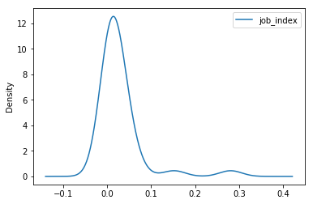

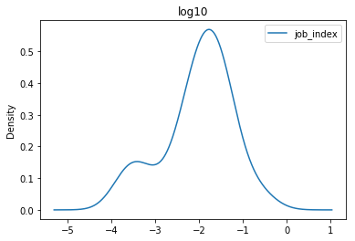

### Cluster European Cities

First I will cluster all the cities in the Data with the same weight on each variable, to get a baseline for the further comparisons.

#### Hierarchical Clustering

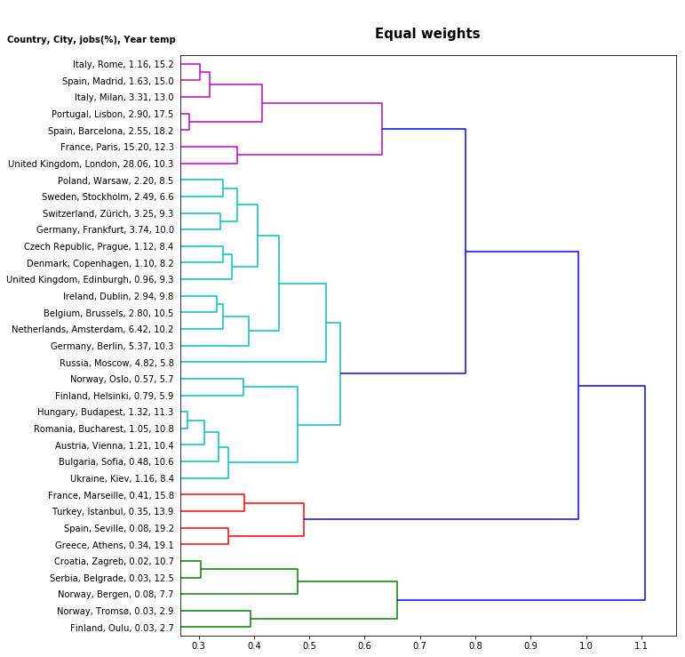

#### Table

|  | Country | City | Year Temp | Jobs (%) | Most common venue | 2nd most common | 3rd most common | 4th most common | 5th most common | Cluster |
| --- | --- | --- | --- | --- | --- | --- | --- | --- | --- | --- |
| 17 | United Kingdom | London | 10.3 | 28.06 | Hotel | Theater | Steakhouse | Indian Restaurant | Seafood Restaurant | 4 |
| 24 | France | Paris | 12.3 | 15.20 | French Restaurant | Plaza | Cocktail Bar | Sandwich Place | Wine Bar | 4 |
| 20 | Italy | Milan | 13.0 | 3.31 | Hotel | Boutique | Ice Cream Shop | Italian Restaurant | Dessert Shop | 4 |
| 16 | Portugal | Lisbon | 17.5 | 2.90 | Plaza | Wine Bar | Portuguese Restaurant | Scenic Lookout | Café | 4 |
| 2 | Spain | Barcelona | 18.2 | 2.55 | Tapas Restaurant | Hotel | Spanish Restaurant | Bookstore | Cocktail Bar | 4 |
| 18 | Spain | Madrid | 15.0 | 1.63 | Restaurant | Plaza | Hotel | Tapas Restaurant | Café | 4 |
| 26 | Italy | Rome | 15.2 | 1.16 | Plaza | Historic Site | Ice Cream Shop | Sandwich Place | Italian Restaurant | 4 |

#### Map the clusters

[interactive chart not shown]

### For Junior Data Scientists

select the 5 best markets, then get the match score between the base city and the others, based on temperature and venues

|  | Country | City | Year Temp | Jobs (%) | Most common venue | 2nd most common | 3rd most common | 4th most common | 5th most common | Match |
| --- | --- | --- | --- | --- | --- | --- | --- | --- | --- | --- |
| 16 | Portugal | Lisbon | 17.5 | 2.90 | Plaza | Wine Bar | Portuguese Restaurant | Scenic Lookout | Café | 100.00 |
| 24 | France | Paris | 12.3 | 15.20 | French Restaurant | Plaza | Cocktail Bar | Sandwich Place | Wine Bar | 58.45 |
| 0 | Netherlands | Amsterdam | 10.2 | 6.42 | Hotel | French Restaurant | Sandwich Place | Bookstore | Restaurant | 51.00 |
| 17 | United Kingdom | London | 10.3 | 28.06 | Hotel | Theater | Steakhouse | Indian Restaurant | Seafood Restaurant | 50.58 |
| 5 | Germany | Berlin | 10.3 | 5.37 | Coffee Shop | Bookstore | Park | History Museum | Monument / Landmark | 49.16 |
| 21 | Russia | Moscow | 5.8 | 4.82 | Plaza | Art Gallery | Road | Bookstore | Hotel | 25.35 |

### For Mid-level Data Scientists

Top 5 cities to move to based on score, with the same weight to the 3 measures

|  | Country | City | Year Temp | Jobs (%) | Most common venue | 2nd most common | 3rd most common | 4th most common | 5th most common | Match |
| --- | --- | --- | --- | --- | --- | --- | --- | --- | --- | --- |
| 16 | Portugal | Lisbon | 17.5 | 2.90 | Plaza | Wine Bar | Portuguese Restaurant | Scenic Lookout | Café | 100.00 |
| 2 | Spain | Barcelona | 18.2 | 2.55 | Tapas Restaurant | Hotel | Spanish Restaurant | Bookstore | Cocktail Bar | 71.76 |
| 26 | Italy | Rome | 15.2 | 1.16 | Plaza | Historic Site | Ice Cream Shop | Sandwich Place | Italian Restaurant | 67.29 |
| 18 | Spain | Madrid | 15.0 | 1.63 | Restaurant | Plaza | Hotel | Tapas Restaurant | Café | 66.36 |
| 20 | Italy | Milan | 13.0 | 3.31 | Hotel | Boutique | Ice Cream Shop | Italian Restaurant | Dessert Shop | 60.49 |
| 19 | France | Marseille | 15.8 | 0.41 | Plaza | Hotel | Bar | French Restaurant | Provençal Restaurant | 59.67 |

### For Senior Data Scientists

get the score with zero weight on job opportunities

|  | Country | City | Year Temp | Jobs (%) | Most common venue | 2nd most common | 3rd most common | 4th most common | 5th most common | Match |
| --- | --- | --- | --- | --- | --- | --- | --- | --- | --- | --- |
| 16 | Portugal | Lisbon | 17.5 | 2.90 | Plaza | Wine Bar | Portuguese Restaurant | Scenic Lookout | Café | 100.00 |
| 2 | Spain | Barcelona | 18.2 | 2.55 | Tapas Restaurant | Hotel | Spanish Restaurant | Bookstore | Cocktail Bar | 71.82 |
| 27 | Spain | Seville | 19.2 | 0.08 | Tapas Restaurant | Spanish Restaurant | Plaza | Hotel | Ice Cream Shop | 71.69 |
| 19 | France | Marseille | 15.8 | 0.41 | Plaza | Hotel | Bar | French Restaurant | Provençal Restaurant | 69.99 |
| 26 | Italy | Rome | 15.2 | 1.16 | Plaza | Historic Site | Ice Cream Shop | Sandwich Place | Italian Restaurant | 69.80 |
| 18 | Spain | Madrid | 15.0 | 1.63 | Restaurant | Plaza | Hotel | Tapas Restaurant | Café | 67.30 |

### For Companies

get the 5 worst markets and get the match score for temperature and venues on them

|  | Country | City | Year Temp | Jobs (%) | Most common venue | 2nd most common | 3rd most common | 4th most common | 5th most common | Match |
| --- | --- | --- | --- | --- | --- | --- | --- | --- | --- | --- |
| 16 | Portugal | Lisbon | 17.5 | 2.90 | Plaza | Wine Bar | Portuguese Restaurant | Scenic Lookout | Café | 100.00 |
| 3 | Serbia | Belgrade | 12.5 | 0.03 | Restaurant | Coffee Shop | Bar | Café | Cocktail Bar | 57.16 |
| 33 | Croatia | Zagreb | 10.7 | 0.02 | Café | Plaza | Bar | Dessert Shop | Restaurant | 53.42 |
| 4 | Norway | Bergen | 7.7 | 0.08 | Bar | Café | Hotel | Coffee Shop | Scandinavian Restaurant | 40.05 |
| 30 | Norway | Tromsø | 2.9 | 0.03 | Hotel | Bar | Café | Grocery Store | Coffee Shop | 15.35 |
| 23 | Finland | Oulu | 2.7 | 0.03 | Grocery Store | Pizza Place | Café | Fast Food Restaurant | Hotel | 11.73 |

```
['Lisbon', 'Barcelona', 'Rome', 'Madrid', 'Milan', 'Marseille']
```

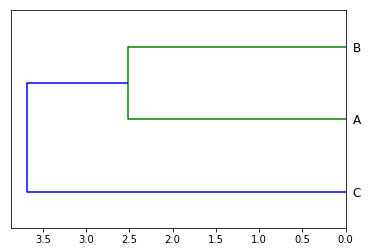

|  | 0 | 1 | 2 | 3 | 4 | 5 | 6 | 7 | 8 | 9 | 10 | 11 | 12 | 13 | 14 |
| --- | --- | --- | --- | --- | --- | --- | --- | --- | --- | --- | --- | --- | --- | --- | --- |
| 0 | 0.192308 | 0.043011 | 0.000000 | 0.000000 | 0.000000 | 0.000000 | 0.000000 | 0.000000 | 0.000000 | 0.000000 | 0.000000 | 0.135417 | 1.000000 | 0.0 | 0.0 |
| 1 | 0.846154 | 0.827957 | 0.864198 | 1.000000 | 1.000000 | 1.000000 | 1.000000 | 1.000000 | 1.000000 | 1.000000 | 1.000000 | 0.916667 | 0.048673 | 0.0 | 0.0 |
| 2 | 1.000000 | 1.000000 | 1.000000 | 0.870130 | 0.727273 | 0.678571 | 0.692308 | 0.735043 | 0.805825 | 0.934066 | 0.939759 | 1.000000 | 0.395280 | 0.0 | 0.0 |
| 3 | 0.000000 | 0.000000 | 0.185185 | 0.493506 | 0.590909 | 0.500000 | 0.461538 | 0.444444 | 0.320388 | 0.208791 | 0.000000 | 0.000000 | 0.000000 | 0.0 | 0.0 |

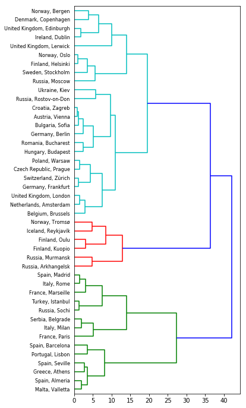

|  | Country | City | Jan | Feb | Mar | Apr | May | Jun | Jul | Aug | Sep | Oct | Nov | Dec | Year | Cluster |
| --- | --- | --- | --- | --- | --- | --- | --- | --- | --- | --- | --- | --- | --- | --- | --- | --- |
| 13 | Greece | Athens | 9.9 | 10.2 | 12.5 | 15.7 | 20.5 | 25.5 | 28.5 | 28.6 | 24.1 | 19.5 | 15.1 | 11.7 | 18.5 | 6 |
| 19 | Malta | Valletta | 12.2 | 12.4 | 13.4 | 15.5 | 19.1 | 23 | 25.9 | 26.3 | 24.1 | 20.7 | 17 | 13.8 | 18.62 | 6 |
| 25 | Portugal | Lisbon | 11.6 | 12.7 | 14.9 | 15.9 | 18 | 21.2 | 23.1 | 23.5 | 22.1 | 18.8 | 15 | 12.4 | 17.5 | 6 |
| 33 | Spain | Almeria | 12.6 | 13.3 | 15.1 | 17 | 19.7 | 23.5 | 26.1 | 26.7 | 24.2 | 20.4 | 16.4 | 13.8 | 19.1 | 6 |
| 34 | Spain | Barcelona | 11.8 | 12.4 | 14.2 | 15.8 | 19.3 | 23 | 25.7 | 26.1 | 23 | 19.5 | 14.9 | 12.3 | 18.2 | 6 |
| 35 | Spain | Seville | 10.9 | 12.5 | 15.6 | 17.3 | 20.7 | 25.1 | 28.2 | 27.9 | 25 | 20.2 | 15.1 | 11.9 | 19.2 | 6 |

[interactive chart not shown]

```
Vienna, Austria
```

```
['43']
```

```
Reykjavík, Iceland
```

```
['0']
```

```
43 - London - United Kingdommom
```

|  | index | City | Country | job_index |
| --- | --- | --- | --- | --- |
| 0 | 0 | Vienna | Austria | 0.013473 |
| 1 | 1 | Brussels | Belgium | 0.026945 |
| 2 | 2 | Sofia | Bulgaria | 0.003868 |
| 3 | 3 | Zagreb | Croatia | 0.000362 |
| 4 | 4 | Prague | Czech Republic | 0.010814 |

```
True
```

|  | Country | City | lat | lon | Jan | Feb | Mar | Apr | May | Jun | Jul | Aug | Sep | Oct | Nov | Dec | Year | Cluster | job_index |
| --- | --- | --- | --- | --- | --- | --- | --- | --- | --- | --- | --- | --- | --- | --- | --- | --- | --- | --- | --- |
| 0 | Austria | Vienna | 48.2084 | 16.3725 | 0.3 | 1.5 | 5.7 | 10.7 | 15.7 | 18.7 | 20.8 | 20.2 | 15.4 | 10.2 | 5.1 | 1.1 | 10.4 | 0 | 0.013473 |
| 1 | Ukraine | Kiev | 50.4501 | 30.5241 | -3.5 | -3 | 1.8 | 9.3 | 15.5 | 18.5 | 20.5 | 19.7 | 14.2 | 8.4 | 1.9 | -2.3 | 8.4 | 0 | 0.010510 |
| 2 | Switzerland | Zürich | 47.3769 | 8.54141 | 0.3 | 1.3 | 5.3 | 8.8 | 13.3 | 16.4 | 18.6 | 18 | 14.1 | 9.9 | 4.4 | 1.4 | 9.3 | 0 | 0.030155 |
| 3 | Romania | Bucharest | 44.4361 | 26.1027 | -1.3 | 0.4 | 5.4 | 11.2 | 16.8 | 20.6 | 22.5 | 22 | 16.9 | 11 | 4.7 | 0.2 | 10.8 | 0 | 0.008451 |
| 4 | Poland | Warsaw | 52.2319 | 21.0067 | -1.8 | -0.6 | 2.8 | 8.7 | 14.2 | 17 | 19.2 | 18.3 | 13.5 | 8.5 | 3.3 | -0.7 | 8.5 | 0 | 0.022389 |

|  | Country | City | lat | lon | Jan | Feb | Mar | Apr | May | Jun | Jul | Aug | Sep | Oct | Nov | Dec | Year | Cluster | job_index |
| --- | --- | --- | --- | --- | --- | --- | --- | --- | --- | --- | --- | --- | --- | --- | --- | --- | --- | --- | --- |
| 0 | Austria | Vienna | 48.208354 | 16.372504 | 0.3 | 1.5 | 5.7 | 10.7 | 15.7 | 18.7 | 20.8 | 20.2 | 15.4 | 10.2 | 5.1 | 1.1 | 10.4 | 0 | 0.013473 |
| 1 | Ukraine | Kiev | 50.450107 | 30.524050 | -3.5 | -3.0 | 1.8 | 9.3 | 15.5 | 18.5 | 20.5 | 19.7 | 14.2 | 8.4 | 1.9 | -2.3 | 8.4 | 0 | 0.010510 |
| 2 | Switzerland | Zürich | 47.376943 | 8.541406 | 0.3 | 1.3 | 5.3 | 8.8 | 13.3 | 16.4 | 18.6 | 18.0 | 14.1 | 9.9 | 4.4 | 1.4 | 9.3 | 0 | 0.030155 |
| 3 | Romania | Bucharest | 44.436141 | 26.102720 | -1.3 | 0.4 | 5.4 | 11.2 | 16.8 | 20.6 | 22.5 | 22.0 | 16.9 | 11.0 | 4.7 | 0.2 | 10.8 | 0 | 0.008451 |
| 4 | Poland | Warsaw | 52.231924 | 21.006727 | -1.8 | -0.6 | 2.8 | 8.7 | 14.2 | 17.0 | 19.2 | 18.3 | 13.5 | 8.5 | 3.3 | -0.7 | 8.5 | 0 | 0.022389 |

```
array([[0.        , 0.00296229, 0.01668224, ..., 0.01287092, 0.00963764,
        0.00695208],
       [0.00296229, 0.        , 0.01964453, ..., 0.00990863, 0.01259993,
        0.00398978],
       [0.01668224, 0.01964453, 0.        , ..., 0.02955316, 0.0070446 ,
        0.02363431],
       ...,
       [0.01287092, 0.00990863, 0.02955316, ..., 0.        , 0.02250856,
        0.00591884],
       [0.00963764, 0.01259993, 0.0070446 , ..., 0.02250856, 0.        ,
        0.01658971],
       [0.00695208, 0.00398978, 0.02363431, ..., 0.00591884, 0.01658971,
        0.        ]])
```

```
array([[1],
       [2],
       [3],
       [4]])
```

```
array([[0., 0., 0.],
       [0., 0., 0.],
       [0., 0., 0.]])
```

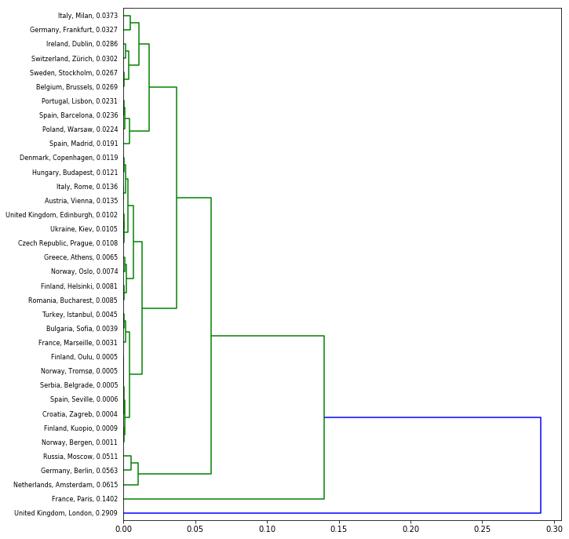

```
array([0, 0, 0, 0, 0, 0, 0, 0, 0, 1, 0, 0, 0, 0, 0, 0, 0, 0, 0, 0, 0, 0,
       0, 0, 0, 0, 0, 0, 0, 0, 2, 0, 0, 0, 0, 0])
```

|  | Country | City | lat | lon | Jan | Feb | Mar | Apr | May | Jun | Jul | Aug | Sep | Oct | Nov | Dec | Year | Cluster | job_index | job_cluster |
| --- | --- | --- | --- | --- | --- | --- | --- | --- | --- | --- | --- | --- | --- | --- | --- | --- | --- | --- | --- | --- |
| 0 | Austria | Vienna | 48.208354 | 16.372504 | 0.3 | 1.5 | 5.7 | 10.7 | 15.7 | 18.7 | 20.8 | 20.2 | 15.4 | 10.2 | 5.1 | 1.1 | 10.4 | 0 | 0.013473 | 0 |
| 19 | Sweden | Stockholm | 59.325117 | 18.071093 | -2.8 | -3.0 | 0.1 | 4.6 | 10.7 | 15.6 | 17.2 | 16.2 | 11.9 | 7.5 | 2.6 | -1.0 | 6.6 | 2 | 0.026681 | 0 |
| 20 | Russia | Moscow | 55.750446 | 37.617494 | -6.5 | -6.7 | -1.0 | 6.7 | 13.2 | 17.0 | 19.2 | 17.0 | 11.3 | 5.6 | -1.2 | -5.2 | 5.8 | 2 | 0.051149 | 0 |
| 21 | Finland | Helsinki | 60.167409 | 24.942568 | -3.9 | -4.7 | -1.3 | 3.9 | 10.2 | 14.6 | 17.8 | 16.3 | 11.5 | 6.6 | 1.6 | -2.0 | 5.9 | 2 | 0.008131 | 0 |
| 22 | Finland | Kuopio | 62.824142 | 27.594561 | -9.2 | -9.2 | -4.1 | 2.0 | 9.1 | 14.5 | 17.5 | 15.0 | 9.7 | 4.1 | -2.0 | -6.7 | 3.4 | 3 | 0.000906 | 0 |
| 23 | Norway | Tromsø | 69.649297 | 18.954849 | -3.8 | -3.7 | -2.3 | 0.7 | 5.1 | 9.2 | 11.8 | 10.9 | 6.9 | 3.2 | -0.6 | -2.7 | 2.9 | 3 | 0.000543 | 0 |
| 24 | Finland | Oulu | 65.011873 | 25.471681 | -9.6 | -9.3 | -4.8 | 1.4 | 7.8 | 13.5 | 16.5 | 14.1 | 8.9 | 3.3 | -2.8 | -7.1 | 2.7 | 3 | 0.000543 | 0 |
| 18 | Norway | Oslo | 59.913330 | 10.738970 | -4.3 | -4.0 | -0.2 | 4.5 | 10.8 | 15.2 | 16.4 | 15.2 | 10.8 | 6.3 | 0.7 | -3.1 | 5.7 | 2 | 0.007393 | 0 |
| 25 | Turkey | Istanbul | 41.009633 | 28.965165 | 5.7 | 5.7 | 7.0 | 11.1 | 15.7 | 20.4 | 22.9 | 23.1 | 19.8 | 15.6 | 11.5 | 8.0 | 13.9 | 4 | 0.004531 | 0 |
| 27 | France | Marseille | 43.296174 | 5.369953 | 8.4 | 8.9 | 11.6 | 13.8 | 17.9 | 21.3 | 24.5 | 24.1 | 20.7 | 16.9 | 11.8 | 9.3 | 15.8 | 4 | 0.003104 | 0 |
| 28 | Italy | Rome | 41.894802 | 12.485338 | 7.5 | 8.2 | 10.2 | 12.6 | 17.2 | 21.1 | 24.1 | 24.5 | 20.8 | 16.4 | 11.4 | 8.4 | 15.2 | 4 | 0.013595 | 0 |
| 29 | Serbia | Belgrade | 44.817813 | 20.456897 | 1.4 | 3.1 | 7.6 | 12.9 | 18.1 | 21.0 | 23.0 | 22.7 | 18.0 | 12.9 | 7.1 | 2.7 | 12.5 | 5 | 0.000543 | 0 |
| 31 | Italy | Milan | 45.466797 | 9.190498 | 2.5 | 4.7 | 9.0 | 12.2 | 17.0 | 20.8 | 23.6 | 23.0 | 19.2 | 13.4 | 7.2 | 3.3 | 13.0 | 5 | 0.037297 | 0 |
| 32 | Spain | Barcelona | 41.382894 | 2.177432 | 11.8 | 12.4 | 14.2 | 15.8 | 19.3 | 23.0 | 25.7 | 26.1 | 23.0 | 19.5 | 14.9 | 12.3 | 18.2 | 6 | 0.023607 | 0 |
| 33 | Spain | Seville | 37.388630 | -5.995317 | 10.9 | 12.5 | 15.6 | 17.3 | 20.7 | 25.1 | 28.2 | 27.9 | 25.0 | 20.2 | 15.1 | 11.9 | 19.2 | 6 | 0.000602 | 0 |
| 26 | Spain | Madrid | 40.416705 | -3.703582 | 6.3 | 7.9 | 11.2 | 12.9 | 16.7 | 22.2 | 25.6 | 25.1 | 20.9 | 15.1 | 9.9 | 6.9 | 15.0 | 4 | 0.019110 | 0 |
| 34 | Portugal | Lisbon | 38.707751 | -9.136592 | 11.6 | 12.7 | 14.9 | 15.9 | 18.0 | 21.2 | 23.1 | 23.5 | 22.1 | 18.8 | 15.0 | 12.4 | 17.5 | 6 | 0.023110 | 0 |
| 17 | Ireland | Dublin | 53.349764 | -6.260273 | 5.3 | 5.3 | 6.8 | 8.3 | 10.9 | 13.6 | 15.6 | 15.3 | 13.4 | 10.5 | 7.4 | 5.6 | 9.8 | 1 | 0.028634 | 0 |
| 15 | Norway | Bergen | 60.394303 | 5.325812 | 1.5 | 1.6 | 3.3 | 5.9 | 10.5 | 13.5 | 14.5 | 14.4 | 11.5 | 8.7 | 4.7 | 2.6 | 7.7 | 1 | 0.001106 | 0 |
| 1 | Ukraine | Kiev | 50.450107 | 30.524050 | -3.5 | -3.0 | 1.8 | 9.3 | 15.5 | 18.5 | 20.5 | 19.7 | 14.2 | 8.4 | 1.9 | -2.3 | 8.4 | 0 | 0.010510 | 0 |
| 2 | Switzerland | Zürich | 47.376943 | 8.541406 | 0.3 | 1.3 | 5.3 | 8.8 | 13.3 | 16.4 | 18.6 | 18.0 | 14.1 | 9.9 | 4.4 | 1.4 | 9.3 | 0 | 0.030155 | 0 |
| 3 | Romania | Bucharest | 44.436141 | 26.102720 | -1.3 | 0.4 | 5.4 | 11.2 | 16.8 | 20.6 | 22.5 | 22.0 | 16.9 | 11.0 | 4.7 | 0.2 | 10.8 | 0 | 0.008451 | 0 |
| 4 | Poland | Warsaw | 52.231924 | 21.006727 | -1.8 | -0.6 | 2.8 | 8.7 | 14.2 | 17.0 | 19.2 | 18.3 | 13.5 | 8.5 | 3.3 | -0.7 | 8.5 | 0 | 0.022389 | 0 |
| 5 | Netherlands | Amsterdam | 52.374540 | 4.897976 | 3.4 | 3.5 | 6.1 | 9.1 | 12.9 | 15.4 | 17.6 | 17.5 | 14.7 | 11.0 | 7.1 | 4.0 | 10.2 | 0 | 0.061536 | 0 |
| 6 | Hungary | Budapest | 47.498382 | 19.040471 | 0.4 | 2.3 | 6.1 | 12.0 | 16.6 | 19.7 | 21.5 | 21.2 | 16.9 | 11.8 | 5.4 | 1.8 | 11.3 | 0 | 0.012104 | 0 |
| 16 | United Kingdom | Edinburgh | 55.953346 | -3.188374 | 4.2 | 4.5 | 6.2 | 8.1 | 10.8 | 13.5 | 15.3 | 15.2 | 13.0 | 9.8 | 6.7 | 4.2 | 9.3 | 1 | 0.010249 | 0 |
| 7 | Germany | Frankfurt | 50.110644 | 8.682092 | 1.0 | 2.0 | 6.0 | 8.0 | 13.0 | 16.0 | 18.0 | 18.0 | 15.0 | 10.0 | 5.0 | 2.0 | 10.0 | 0 | 0.032718 | 0 |
| 10 | Croatia | Zagreb | 45.813177 | 15.977048 | 0.3 | 2.3 | 6.4 | 10.7 | 15.8 | 18.8 | 20.6 | 20.1 | 15.9 | 10.5 | 5.0 | 1.4 | 10.7 | 0 | 0.000362 | 0 |
| 11 | Czech Republic | Prague | 50.087465 | 14.421254 | -1.4 | -0.4 | 3.6 | 8.4 | 13.4 | 16.1 | 18.2 | 17.8 | 13.5 | 8.5 | 3.1 | -0.3 | 8.4 | 0 | 0.010814 | 0 |
| 12 | Bulgaria | Sofia | 42.697863 | 23.322179 | -0.5 | 1.1 | 5.4 | 10.6 | 15.4 | 18.9 | 21.2 | 21.0 | 16.5 | 11.3 | 5.1 | 0.7 | 10.6 | 0 | 0.003868 | 0 |
| 13 | Belgium | Brussels | 50.846557 | 4.351697 | 3.3 | 3.7 | 6.8 | 9.8 | 13.6 | 16.2 | 18.4 | 18.0 | 14.9 | 11.1 | 6.8 | 3.9 | 10.5 | 0 | 0.026945 | 0 |
| 14 | Denmark | Copenhagen | 55.686724 | 12.570072 | 0.6 | 0.5 | 2.5 | 6.1 | 11.1 | 14.8 | 16.9 | 16.7 | 13.1 | 9.1 | 4.9 | 2.1 | 8.2 | 1 | 0.011937 | 0 |
| 8 | Germany | Berlin | 52.517036 | 13.388860 | 0.6 | 2.3 | 5.1 | 10.2 | 14.8 | 17.9 | 20.3 | 19.7 | 15.3 | 10.5 | 6.0 | 1.3 | 10.3 | 0 | 0.056284 | 0 |
| 35 | Greece | Athens | 37.984149 | 23.727984 | 9.9 | 10.2 | 12.5 | 15.7 | 20.5 | 25.5 | 28.5 | 28.6 | 24.1 | 19.5 | 15.1 | 11.7 | 18.5 | 6 | 0.006521 | 0 |
| 9 | United Kingdom | London | 51.507322 | -0.127647 | 4.3 | 4.5 | 6.9 | 8.7 | 12.1 | 15.1 | 17.3 | 17.0 | 14.3 | 10.9 | 7.2 | 4.7 | 10.3 | 0 | 0.290895 | 1 |
| 30 | France | Paris | 48.856610 | 2.351499 | 4.9 | 5.6 | 8.8 | 11.4 | 15.1 | 18.2 | 20.4 | 20.2 | 16.9 | 12.9 | 8.1 | 5.4 | 12.3 | 5 | 0.140200 | 2 |

[output not shown]

[output cut: 125 more lines]

[output not shown]

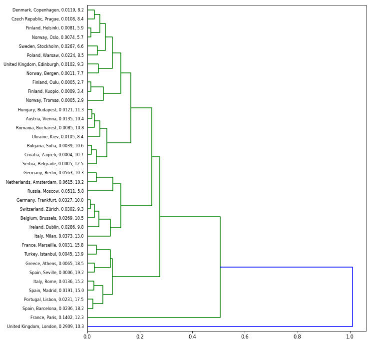

[figure not shown]

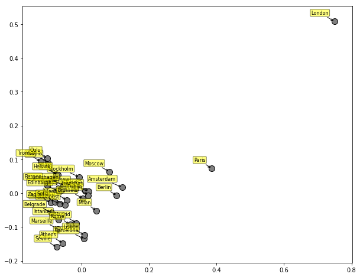

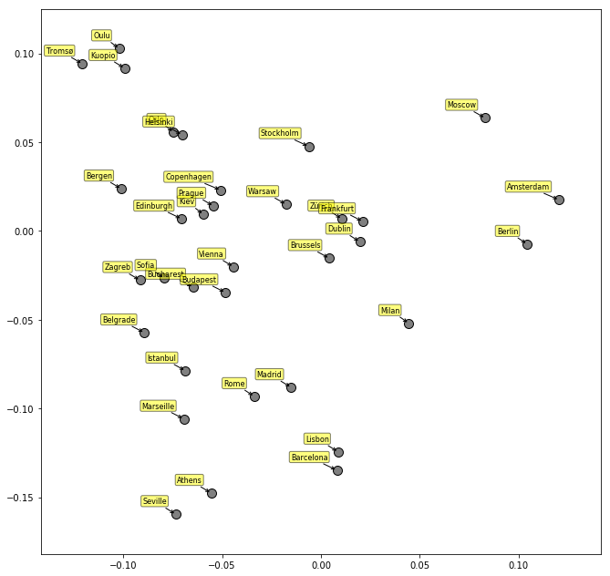

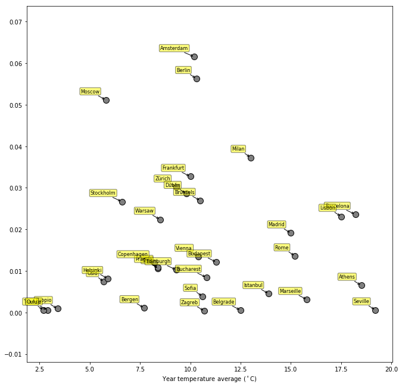

```
array([[0.        , 0.03831554, 0.06302293, ..., 0.14577899, 0.12166634,
        0.13140109],
       [0.03831554, 0.        , 0.0781915 , ..., 0.17521283, 0.15900134,
        0.16152951],
       [0.06302293, 0.0781915 , 0.        , ..., 0.18711668, 0.13232339,
        0.16895081],
       ...,
       [0.14577899, 0.17521283, 0.18711668, ..., 0.        , 0.08933197,
        0.02791191],
       [0.12166634, 0.15900134, 0.13232339, ..., 0.08933197, 0.        ,
        0.074573  ],
       [0.13140109, 0.16152951, 0.16895081, ..., 0.02791191, 0.074573  ,
        0.        ]])
```

```
36
```

|  | Lisbon |
| --- | --- |
| Barcelona | 98.0 |
| Rome | 94.0 |
| Madrid | 94.0 |
| Athens | 93.0 |
| Marseille | 92.0 |
| Seville | 91.0 |
| Istanbul | 91.0 |
| Milan | 90.0 |
| Brussels | 89.0 |

```
Kiev
```

[interactive chart not shown]

|  | city | cl |
| --- | --- | --- |
| 34 | Lisbon | 4 |
| 32 | Barcelona | 4 |
| 24 | Oulu | 3 |
| 22 | Kuopio | 3 |
| 18 | Oslo | 2 |
| 21 | Helsinki | 2 |
| 2 | Zürich | 1 |
| 7 | Frankfurt | 1 |
| 10 | Zagreb | 0 |
| 12 | Sofia | 0 |
| 0 | Vienna | 0 |
| 3 | Bucharest | 0 |
| 6 | Budapest | 0 |
| 11 | Prague | -1 |
| 5 | Amsterdam | -1 |
| 33 | Seville | -1 |
| 4 | Warsaw | -1 |
| 31 | Milan | -1 |
| 30 | Paris | -1 |
| 29 | Belgrade | -1 |
| 28 | Rome | -1 |
| 27 | Marseille | -1 |
| 26 | Madrid | -1 |
| 25 | Istanbul | -1 |
| 23 | Tromsø | -1 |
| 9 | London | -1 |
| 8 | Berlin | -1 |
| 20 | Moscow | -1 |
| 19 | Stockholm | -1 |
| 1 | Kiev | -1 |
| 17 | Dublin | -1 |
| 16 | Edinburgh | -1 |
| 15 | Bergen | -1 |
| 14 | Copenhagen | -1 |
| 13 | Brussels | -1 |
| 35 | Athens | -1 |

# Car Crash Course

start

Capstone Project - The Battle of Neighborhoods (Week 1) | Coursera https://www.coursera.org/learn/applied-data-science-capstone/peer/60zST/capstone-project-the-battle-of-neighborhoods-week-1/submit

Github Markdown Heading Anchors https://gist.github.com/asabaylus/3071099

python - Display cluster labels for a scipy dendrogram - Stack Overflow https://stackoverflow.com/questions/35873273/display-cluster-labels-for-a-scipy-dendrogram

List of European cities by temperature - Wikipedia https://en.wikipedia.org/wiki/List_of_European_cities_by_temperature

When to use weighted Euclidean distance and how to determine the weights to use? - Cross Validated https://stats.stackexchange.com/questions/15289/when-to-use-weighted-euclidean-distance-and-how-to-determine-the-weights-to-use

Hierarchical clustering (scipy.cluster.hierarchy) — SciPy v0.18.0 Reference Guide https://docs.scipy.org/doc/scipy-0.18.0/reference/cluster.hierarchy.html

scipy.cluster.hierarchy.dendrogram — SciPy v0.18.0 Reference Guide https://docs.scipy.org/doc/scipy-0.18.0/reference/generated/scipy.cluster.hierarchy.dendrogram.html#scipy.cluster.hierarchy.dendrogram

scipy.cluster.hierarchy.single — SciPy v0.18.0 Reference Guide https://docs.scipy.org/doc/scipy-0.18.0/reference/generated/scipy.cluster.hierarchy.single.html#scipy.cluster.hierarchy.single

scipy.cluster.hierarchy.fclusterdata — SciPy v0.18.0 Reference Guide https://docs.scipy.org/doc/scipy-0.18.0/reference/generated/scipy.cluster.hierarchy.fclusterdata.html#scipy.cluster.hierarchy.fclusterdata

python - Use Distance Matrix in scipy.cluster.hierarchy.linkage()? - Stack Overflow https://stackoverflow.com/questions/18952587/use-distance-matrix-in-scipy-cluster-hierarchy-linkage

Use pdist() in python with a custom distance function defined by you - Stack Overflow https://stackoverflow.com/questions/36422949/use-pdist-in-python-with-a-custom-distance-function-defined-by-you

scipy.spatial.distance.pdist — SciPy v0.17.0 Reference Guide https://docs.scipy.org/doc/scipy-0.17.0/reference/generated/scipy.spatial.distance.pdist.html#scipy.spatial.distance.pdist

numpy.array — NumPy v1.15 Manual https://docs.scipy.org/doc/numpy-1.15.1/reference/generated/numpy.array.html

numpy - Calculate weighted pairwise distance matrix in Python - Stack Overflow https://stackoverflow.com/questions/20089007/calculate-weighted-pairwise-distance-matrix-in-python

hierarchy.dendrogram plt set label - Google Search https://www.google.pt/search?q=hierarchy.dendrogram+plt+set+label&oq=hierarchy.dendrogram+plt+set+label&aqs=chrome..69i57.12325j1j7&sourceid=chrome&ie=UTF-8

# 401 Customised dendrogram – The Python Graph Gallery

https://python-graph-gallery.com/401-customised-dendrogram/